# Loan Data from Prosper - Communicate Data Findings

## Introduction

#### About Prosper

Prosper was founded in 2005 as the first peer-to-peer lending marketplace in the United States. Since then, Prosper has facilitated more than $ \$19$ billion in loans to more than 1,110,000 people.<br> Through Prosper, people can invest in each other in a way that is financially and socially rewarding. Borrowers apply online for a fixed-rate, fixed-term loan between $\$2,000$ and $\$40,000$. Individuals and institutions can invest in the loans and earn attractive returns. Prosper handles all loan servicing on behalf of the matched borrowers and investors. More: https://www.prosper.com/about

#### About Dataset

This data set (prosperLoanData.csv) contains 113 937 loans in the period 9.11.2005 - 10.3.2014. Dataset contains 81 variables on each loan, including loan amount, borrower rate (or interest rate), current loan status, borrower income, and many others. Additional explanatory file on these variables is called prosper_LoanData_explain_variables.csv and this jupyter notebook file should be distributed with it.

#### Questions for analysis

What factors affect a loan’s outcome status?

What affects the borrower’s APR or interest rate?

Are there differences between loans depending on how large the original loan amount was?

Look at the data variables and try to anticipate which of them are worth for answering these questions.

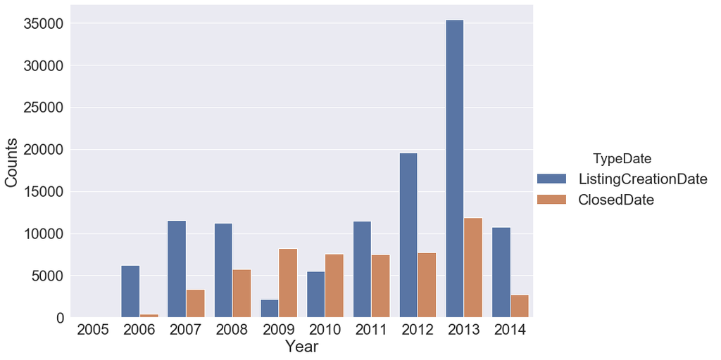

```python
sb.set_context("paper", rc={"font.size":18,"axes.titlesize":18,"axes.labelsize":18})
sb.set(font_scale = 2)

ax=sb.catplot(x='Year', y='Counts', hue='TypeDate', data=df_sub, kind='bar', height=8, aspect=12/8);


plt.show()
```

OnData represents business grow in the period 9.11.2005 - 10.3.2014. In the plot above we can see there is a grow in the borrower number. However, there was a stagnation in years 2009 and 2010.

## Exploratory Analysis

### Questions for analysis

What factors affect a loan’s outcome status? Supposed: "D"

What affects the borrower’s APR or interest rate?

Are there differences between loans depending on how large the original loan amount was?

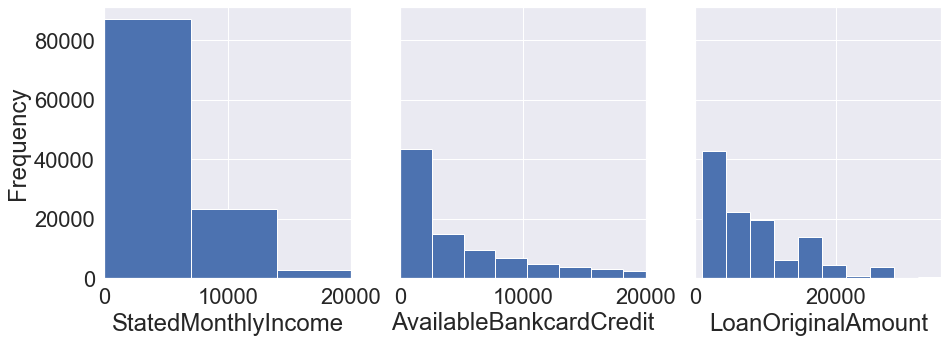

```python
plt.figure(figsize=(15,5))
plt.subplot(131)
ax1=df1['StatedMonthlyIncome'].plot(kind="hist", bins=250);
plt.xlim([0,20000])
plt.xlabel('StatedMonthlyIncome');
plt.subplot(132, sharey=ax1)
ax2=df1['AvailableBankcardCredit'].plot(kind="hist", bins=250);
plt.xlim([0,20000])
plt.xlabel('AvailableBankcardCredit');
plt.subplot(133, sharey=ax1)
df1['LoanOriginalAmount'].plot(kind="hist", bins=10);
plt.xlim([0,35000])
plt.xlabel('LoanOriginalAmount');
```

**Plot 2 is showing distribution of StatedMonthlyIncome, AvailableBankCredit and LoanOriginalAmount. We can see the most populated are the lowest values of these variables: StatedMonthlyIncome<5000, AvailableBankCredit<2500, LoanOriginalAmount<5000.**

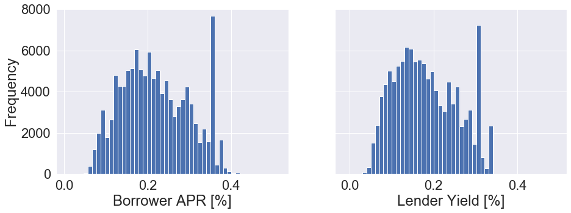

```python
plt.figure(figsize=(15,5))
plt.subplot(121)
ax1=df1['BorrowerAPR'].plot(kind="hist", bins=50);
plt.xlabel('Borrower APR [%]');
plt.subplot(122, sharey=ax1)
ax2=df1['LenderYield'].plot(kind="hist", bins=50);
plt.xlabel('Lender Yield [%]');
```

**Plot 3 is showing histogram of Borrower APR and Lender Yield.They look very similar.**

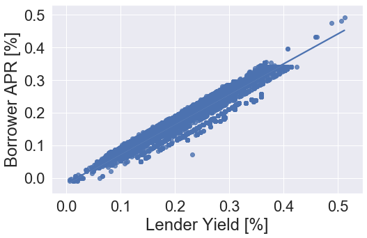

```python
plt.figure(figsize=[8, 5])
sb.regplot(data = df1, x = 'BorrowerAPR', y = 'LenderYield');
plt.xlabel('Lender Yield [%]');
plt.ylabel('Borrower APR [%]');
```

**Plot 4 is showing there is a strong correlation between Borrowers APR and Lender Yield. This again confirms that a lender will earn the most on people with lower ratings and therefore higher Borrower APR.**

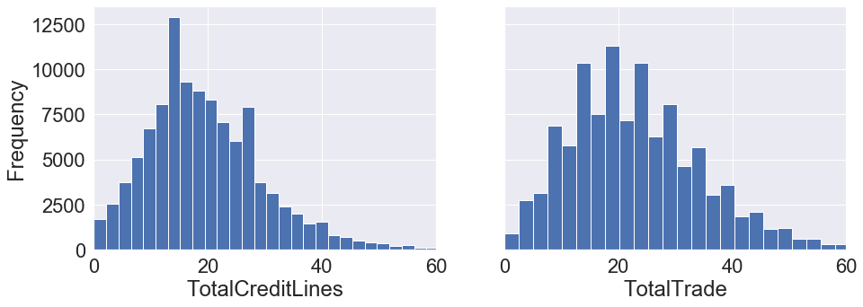

```python
plt.figure(figsize=(15,5))
plt.subplot(121)
ax1=df1['TotalCreditLines'].plot(kind="hist", bins=50);
plt.xlabel('TotalCreditLines');
plt.xlim([0,60]);
plt.subplot(122, sharey=ax1)
ax2=df1['TotalTrades'].plot(kind="hist", bins=50);
plt.xlabel('TotalTrade');
plt.xlim([0,60]);
```

**Plot 5 - Total Credit Lines and Total Trades distribution.**

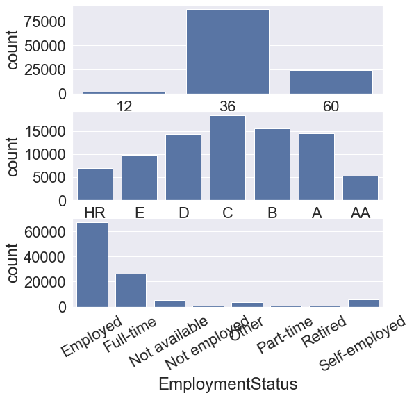

```python
fig, ax = plt.subplots(nrows=3, figsize = [8,8])
sb.set(font_scale = 1.2)
sb.set_style(style='white')
default_color = sb.color_palette()[0]
sb.countplot(data = df1, x = 'Term', color = default_color, ax = ax[0])
sb.countplot(data = df1, x = 'ProsperRating', color = default_color, ax = ax[1])
sb.countplot(data = df1, x = 'EmploymentStatus', color = default_color, ax = ax[2])

plt.xticks(rotation=30);
```

**Plot 6: Categorical variables: The length of most of the loans is 36 months. The ratings of the most of the borrowers are among D to A, while most populated is the C. The most borrowers are employed anfd full-time.**

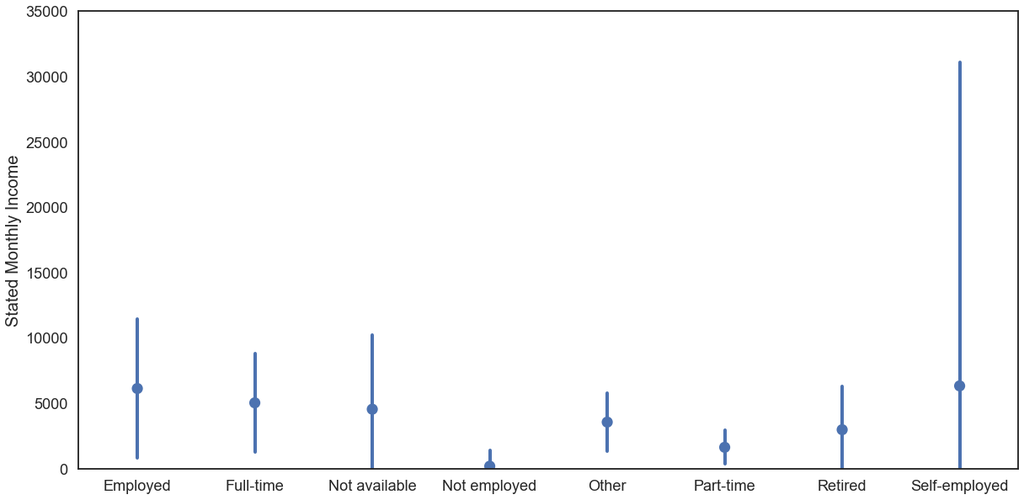

```python
base_color = sb.color_palette()[1]

plt.figure(figsize = [20, 10])

sb.set_context("talk", font_scale=1.1)
base_color = sb.color_palette()[0]

ax1=sb.pointplot(data=df1, x='EmploymentStatus', y='StatedMonthlyIncome', color=base_color, ci='sd', linestyles="")

ax1.set_ylabel('Stated Monthly Income',fontsize=20)
ax1.set_xlabel('')
ax1.grid(False)
plt.ylim([0,35000]);
```

## Explanatory Analysis

## What factors affect a loan’s outcome status?

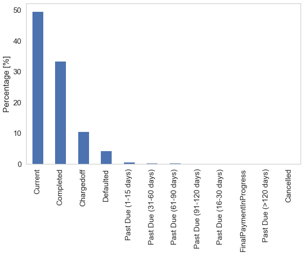

```python
plt.figure(figsize=[10,6]);

xx=df1['LoanStatus'].value_counts(normalize=True)*100
xx.plot(kind="bar");
plt.ylabel('Percentage [%]');
plt.grid(False);
```

The visible proportion has the categories Current, Completed, Chargedoff and Defaulted.

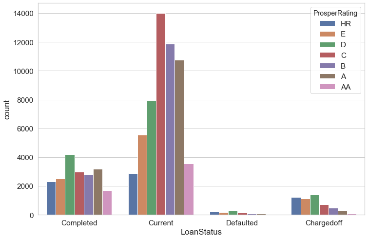

```python
plt.figure(figsize = [12, 8])

sb.countplot(x="LoanStatus",hue='ProsperRating', data=df1_sub)
```

We can see that in the group with Current LoanStatus, the most frequent is the C ProsperRating. For the Completed, Defaulted and Chargedoff it is D ProsperRating.

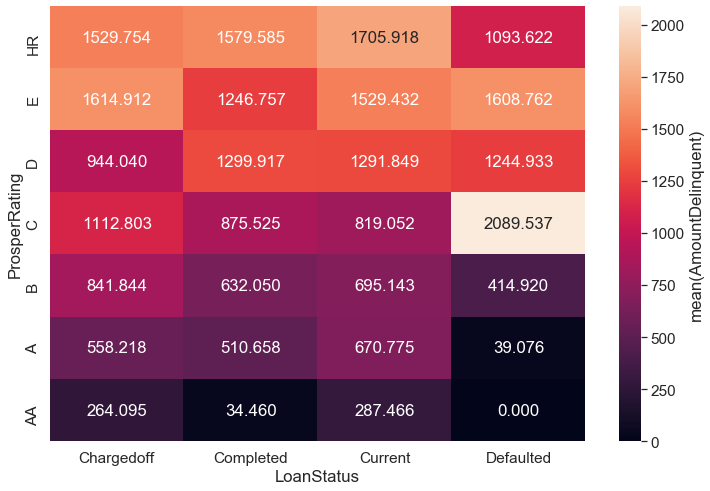

```python
plt.figure(figsize = [12, 8])

cat_means = df1_sub.groupby(['LoanStatus', 'ProsperRating']).mean()['AmountDelinquent']
cat_means = cat_means.reset_index(name = 'AmountDelinquent')

cat_means = cat_means.pivot(index = 'ProsperRating', columns = 'LoanStatus',
                            values = 'AmountDelinquent')
sb.heatmap(cat_means, annot = True, fmt = '.3f',
           cbar_kws = {'label' : 'mean(AmountDelinquent)'});
```

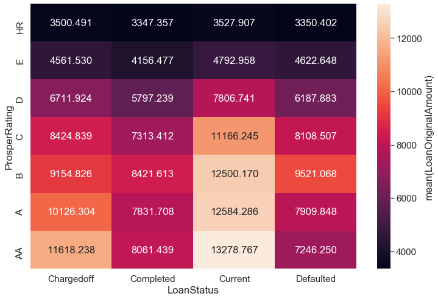

```python
plt.figure(figsize = [12, 8])

cat_means = df1_sub.groupby(['LoanStatus', 'ProsperRating']).mean()['LoanOriginalAmount']
cat_means = cat_means.reset_index(name = 'LoanOriginalAmount')

cat_means = cat_means.pivot(index = 'ProsperRating', columns = 'LoanStatus',
                            values = 'LoanOriginalAmount')
sb.heatmap(cat_means, annot = True, fmt = '.3f',
           cbar_kws = {'label' : 'mean(LoanOriginalAmount)'});
```

From the about heatmap we cans that highest mean Loan Original Amounts have the borrowers with the loan status Current and with highest ratings (AA, A, B). The second group with the highest mean Loan Original Amount is the "charged-off" group.

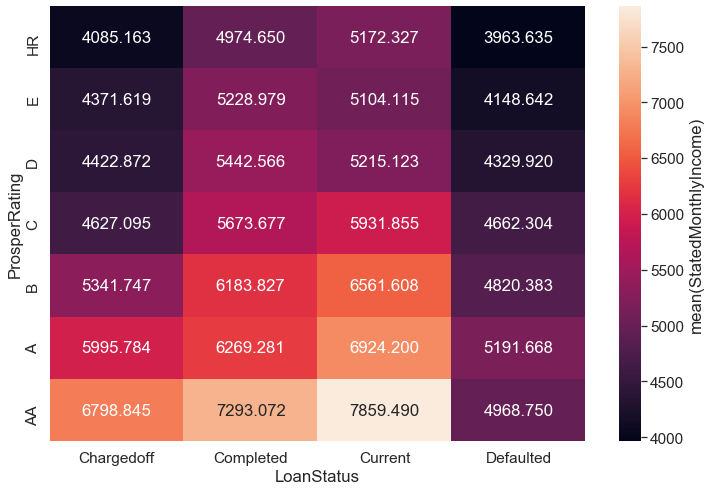

```python
plt.figure(figsize = [12, 8])

cat_means = df1_sub.groupby(['LoanStatus', 'ProsperRating']).mean()['StatedMonthlyIncome']
cat_means = cat_means.reset_index(name = 'StatedMonthlyIncome')

cat_means = cat_means.pivot(index = 'ProsperRating', columns = 'LoanStatus',
                            values = 'StatedMonthlyIncome')
sb.heatmap(cat_means, annot = True, fmt = '.3f',
           cbar_kws = {'label' : 'mean(StatedMonthlyIncome)'});
```

We can see that borrowers with the highest incomes belong to the LoanStatus groups Current and then Completed. Status Defaulted have borrowers with the lowest incomes.

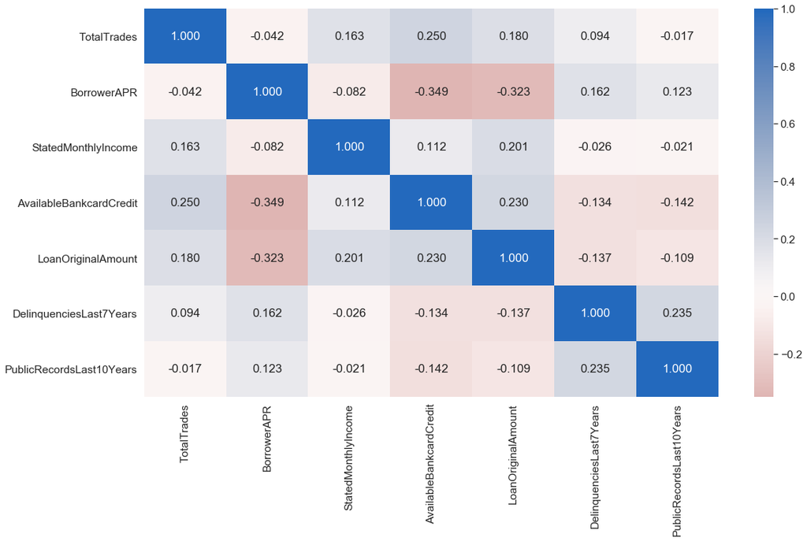

```python
# correlation plot

sb.set(font_scale=1.4)
plt.figure(figsize = [18, 10])
sb.heatmap(df1[num_vars].corr(), annot = True, fmt = '.3f',
           cmap = 'vlag_r', center = 0);
```

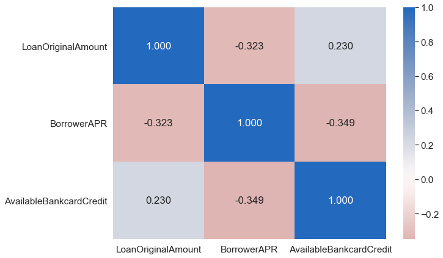

```python
# correlation plot
plt.figure(figsize = [10, 7])
sb.heatmap(df1[num_vars].corr(), annot = True, fmt = '.3f',
           cmap = 'vlag_r', center = 0);
```

Correlation Matrix: We can see that there is a weak negative correlation between BorrowerAPR and LoanOriginalAmount and AvailableBankCredit. Other variables in df1 have even lower correlations coefficients with Borrower APR.

We can also see positive weak correlation between LoanOriginalAmount and StatedMonthlyIncome as well as between LoanOriginalAmount and AvailableBankcardCredit.

Comparing histograms of BorrowerAPR with other variables, we can see while distribution of BorrowerAPR is wide and central (closed to normal), other distributions are very right-skewed.

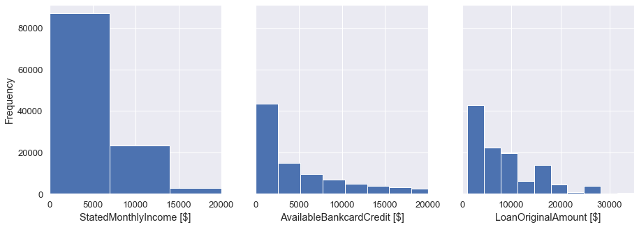

```python
plt.figure(figsize=(15,5))
plt.subplot(131)
ax1=df1['StatedMonthlyIncome'].plot(kind="hist", bins=250);
plt.xlim([0,20000])
plt.xlabel('StatedMonthlyIncome [$]');
plt.subplot(132, sharey=ax1)
ax2=df1['AvailableBankcardCredit'].plot(kind="hist", bins=250);
plt.xlim([0,20000])
plt.xlabel('AvailableBankcardCredit [$]');
plt.subplot(133, sharey=ax1)
df1['LoanOriginalAmount'].plot(kind="hist", bins=10);
plt.xlim([0,35000])
plt.xlabel('LoanOriginalAmount [$]');
```

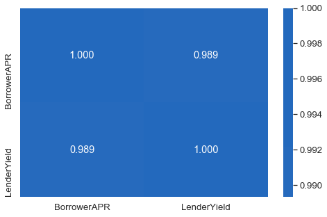

```python
num_vars = ['BorrowerAPR', 'LenderYield']
# correlation plot
plt.figure(figsize = [8, 5])
sb.heatmap(df1[num_vars].corr(), annot = True, fmt = '.3f',
           cmap = 'vlag_r', center = 0);
```

There is a strong correlation between Borrowers APR and Lender Yield. This confirms that a lender will earn the most on people with lower higher Borrower APR.

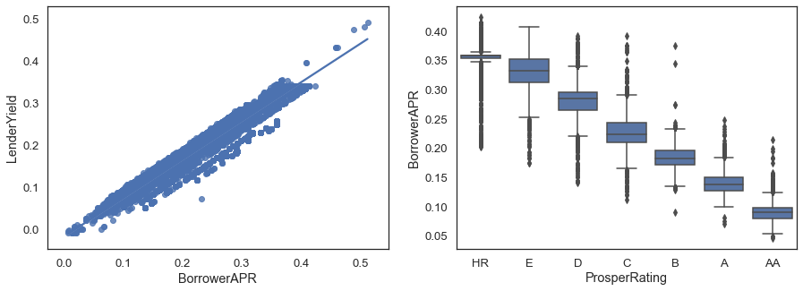

```python
sb.set_style(style='white')

fig, axes = plt.subplots(1, 2, figsize=(15, 5), sharey=False)
sb.regplot(ax=axes[0], data = df1, x = 'BorrowerAPR', y = 'LenderYield');
sb.boxplot(ax=axes[1], x='ProsperRating', y='BorrowerAPR', data=df1, color=base_color);
```

**Borrowers with higher Prosper Rating have lower APR. There is a strong correlation between Borrowers APR and Prosper Rating score. There is also a strong correlation between borrower APR and LenderYield. That indicates that lender will earn the most on people with lower ratings.**

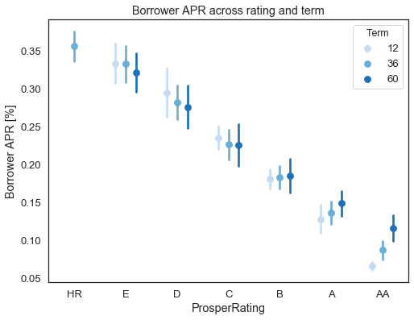

```python
sb.set_style(style='white')
fig = plt.figure(figsize = [8,6])
ax = sb.pointplot(data = df1, x = 'ProsperRating', y = 'BorrowerAPR', hue = 'Term',
           palette = 'Blues', linestyles = '', dodge = 0.4, ci='sd')
plt.title('Borrower APR across rating and term')
plt.ylabel('Borrower APR [%]')
ax.set_yticklabels([],minor = True);
```

Interestingly, the borrower APR decrease with the increase of borrow term for people with HR-C ratings. But for people with B-AA ratings, the APR increase with the increase of borrow term.

## Are there differences between loans depending on how large the original loan amount was?

I created 4 loan groups based on ther LoanOriginalAmount called df1_loan1, df1_loan2, df1_loan3,df1_loan4.

LoanOriginalAmount limits are 10000 for df1_loan1, 20000 for df1_loan2, 30000 df1_loan3 and higher than 30000 is represented in df1_loan4 groups.

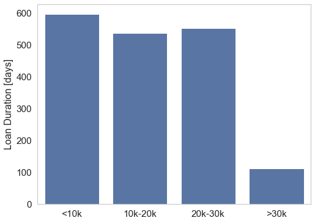

```python
plt.figure(figsize=(8,6))
sb.set(font_scale = 1.4)
sb.set_style("whitegrid")

y=[strfdelta((df1_loan1['ClosedDate']-df1_loan1['LoanOriginationDate']).mean(),"{days}"),strfdelta((df1_loan2['ClosedDate']-df1_loan2['LoanOriginationDate']).mean(),"{days}"), strfdelta((df1_loan3['ClosedDate']-df1_loan3['LoanOriginationDate']).mean(),"{days}"),strfdelta((df1_loan4['ClosedDate']-df1_loan4['LoanOriginationDate']).mean(),"{days}")]
x=["<10k","10k-20k","20k-30k", ">30k"]
ax=sb.barplot(x,y, color=base_color);
ax.set_ylabel('Loan Duration [days]',fontsize=16);
ax.grid(False)
```

Plot about shows that the borrowers with the highest LoanOriginalAmount have the shortest period between LoanOriginationDate and ClosedDate.

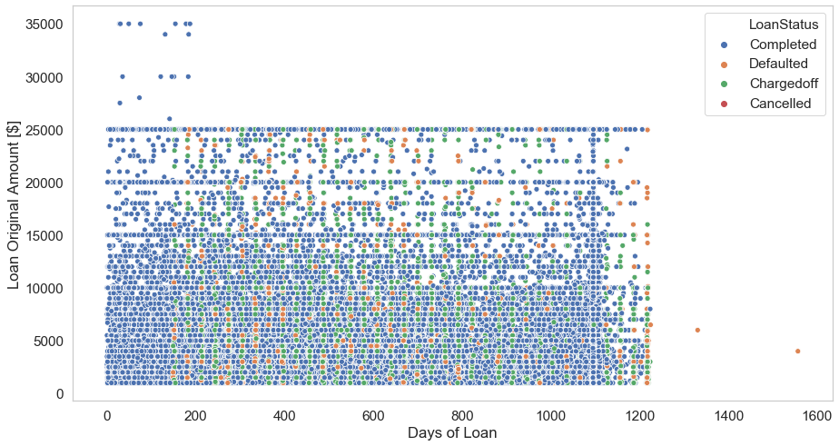

```python
plt.figure(figsize=[15, 8])
sb.set(font_scale = 1.4)
sb.set_style("whitegrid")
ax=sb.scatterplot(data = df1_sub2, x = 'DaysLoan', y = 'LoanOriginalAmount', hue="LoanStatus");
plt.xlabel('Days of Loan');
plt.ylabel('Loan Original Amount [$]');
ax.grid(False)
```

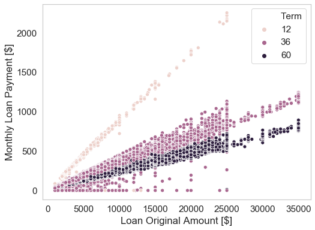

```python
plt.figure(figsize=[8, 6])
sb.set(font_scale = 1.4)
sb.set_style("whitegrid")

ax=sb.scatterplot(x="LoanOriginalAmount", y='MonthlyLoanPayment', data=df1, hue='Term', legend="full");
ax.grid(False)
plt.ylabel('Monthly Loan Payment [$]')
plt.xlabel('Loan Original Amount [$]');
```

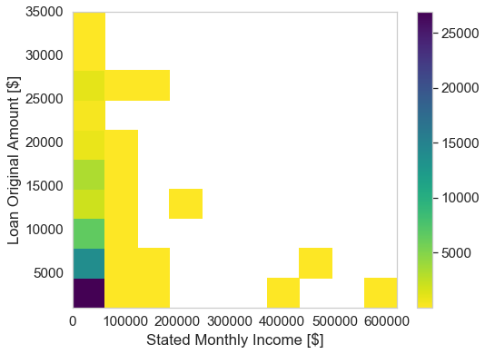

```python
plt.figure(figsize=[8, 6])
sb.set(font_scale = 1.4)
sb.set_style("whitegrid")
plt.hist2d(data = df1_sub2, x = 'StatedMonthlyIncome', y = 'LoanOriginalAmount', cmin=0.5, cmap='viridis_r')
plt.colorbar()
plt.xlabel('Stated Monthly Income [$]')
plt.ylabel('Loan Original Amount [$]');
```

In this plot we can see that most of borrowers have salaries in range \$0-50000 and LoanOriginalAmount is less than \\$5000

## Main findings

#### Are there differences between loans depending on how large the original loan amount was?

1. The highest loan original amounts (>$25000) are paid by borrowers within ca. 200 days. According to the previous findings, these borrowers have also the highest ratings (AA, A, B).
2. The longest loans are Defaulted loans. According to the previous findings, these borrowers have the lowest inomes of all loan status categories.
3. The most of borrowers have salaries in range \$0-50000 and loan original amount is less than \$5000.

## Sources

https://github.com/yduan004/communicate-data-loan-data-from-Prosper/blob/master/exploration.ipynb https://stackoverflow.com/questions/8906926/formatting-timedelta-objects